# Projekt č. 1

# Příklad č. 2: Dvojvýběrové testy o rovnosti korelačních koeficientů $\rho_1$ a $\rho_2$, silofunkce a minimální rozsah souboru

### Zadání

Majme $H_{01} : \rho_1 - \rho_2 = \rho_0$ oproti alternatívnej hypotéze $H_{11} : \rho_1 - \rho_2 \ne \rho_0$, ktorú testujeme dvojvýberovou $ z $-štatistikou $z_W$.

1. Odvoďte silofunkciu
   $$1 - \beta(\xi_1, \xi_2) = 1 - \Phi \left( u_{\alpha/2} - \sqrt{(n - 3)/2} \cdot |\delta_\xi| \right),$$
   kde
   $$\xi = \frac{1}{2} \ln \left( \frac{1 + \rho}{1 - \rho} \right),
   \quad \delta_\xi = \xi_0 - (\xi_1 - \xi_2),
   \quad n_2 = n_1 = n.$$
2. Odvoďte vzorec na výpočet minimálneho rozsahu súboru
   $$n_1 \geq 3 + 2 \left( \frac{u_{\alpha/2} + u_\beta}{\xi_1 - \xi_2 - \xi_0} \right)^2,
   \quad n_2 = k n_1,$$
   kde $k$ je alokačný pomer.

# Příklad č. 3: Test o rozdílu dvou korelačních koeficientů

### Zadání

Majme dátový súbor `one-sample-correlation-skull-mf.txt`, premennú `skull_pH` opisujúcu najväčšiu výšku mozgovne lebky (v mm) a premennú `face_H` opisujúcu morfologickú výšku tváre (v mm).

Na hladine významnosti $\alpha = 0.05$ zistite, či sa korelačný koeficient medzi najväčšou výškou mozgovne lebky a morfologickou výškou tváre u mužov líši od korelačného koeficientu medzi rovnakými premennými u žien.

Pred testovaním overte splnenie predpokladu dvojrozmernej normality oboch náhodných výberov pomocou Mardiovho testu.

Testovanie vykonajte pomocou:

- 1. kritického oboru,
- 2. intervalu spoľahlivosti (iba vo Waldovom prípade),
- 3. $p$-hodnoty s použitím testových štatistík:
  1. $Z_W$,
  2. $U_{LR}$.

```r
library(MVN)

data <- read.delim('one-sample-correlation-skull-mf.txt', sep = '\t', dec = '.')

data_M <- data[data$sex == "m", c('skull_pH', 'face_H')]
data_M <- na.omit(data_M)
skull_M <- data_M$skull_pH
face_M <- data_M$face_H

data_F <- data[data$sex == "f", c('skull_pH', 'face_H')]
data_F <- na.omit(data_F)
skull_F <- data_F$skull_pH
face_F <- data_F$face_H
```

## Test dvojrozměrné normality u mužů

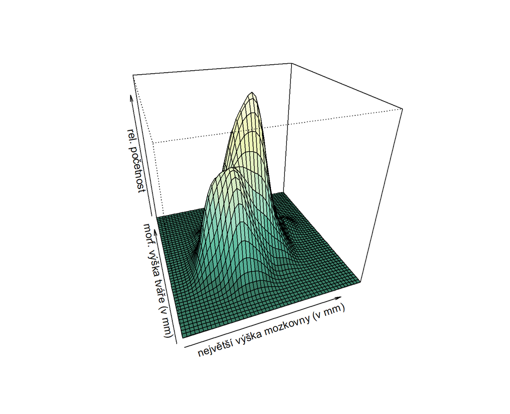

```r
mardia_M <- MVN::mvn(data_M, mvnTest = 'mardia')$multi
p_vals_M <- as.numeric(levels(mardia_M$`p value`))

kd <- MASS::kde2d(skull_M, face_M, n = 50, lims = c(120, 155, 90, 145))
x <- kd$x
y <- kd$y
Z <- kd$z

N <- dim(Z)[1]
stredy <- Z[-1, -1] + Z[-1, -N] + Z[-N, -1] + Z[-N, -N]
vyska <- cut(stredy, 12)

paleta <- colorRampPalette(c(
  "#3A7D66", "#4ea78e", "#66c2a4", "#9adbc3", "#cde9c5", "#e3f3c3", "#f0f6b5", "#f6f8d3"))

persp(x, y, Z,  theta = -20, phi = 30, col = paleta(12)[vyska],
      xlab = "největší výška mozkovny (v mm)", ylab = "morf. výška tváře (v mm)",
      zlab = "rel. početnost")
```

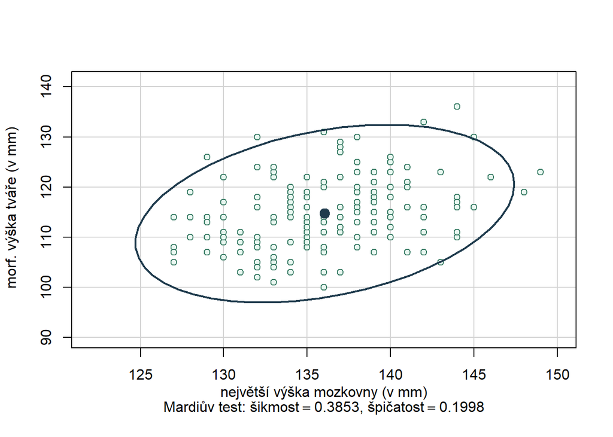

```r
car::dataEllipse(skull_M, face_M, level = 0.95, xlim = c(122, 150),
                 ylim = c(90, 141), pch = 21, bg = "#e8f7f0", col = c('#3A7D66', '#1F3B4D'),
                 ylab = " morf. výška tváře (v mm)", xlab = "")
mtext("největší výška mozkovny (v mm)", side = 1, line = 2)
mtext(bquote(paste("Mardiův test: šikmost" == .(round(p_vals_M[1], 4)), ', ',
                   "špičatost" == .(round(p_vals_M[2], 4)))), side = 1, line = 3)
```

## Test dvojrozměrné normality u žen

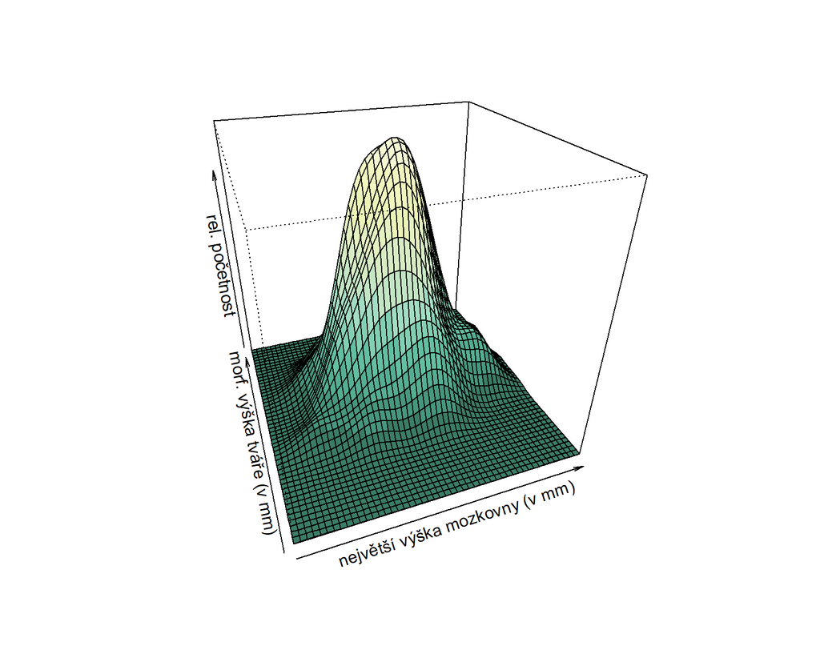

```r
mardia_F <- MVN::mvn(data_F, mvnTest = 'mardia')$multi
p_vals_F <- as.numeric(levels(mardia_F$`p value`))

kd <- MASS::kde2d(skull_F, face_F, n = 50, lims = c(115, 145, 80, 130))
x <- kd$x
y <- kd$y
Z <- kd$z

N <- dim(Z)[1]
stredy <- Z[-1, -1] + Z[-1, -N] + Z[-N, -1] + Z[-N, -N]
vyska <- cut(stredy, 12)

persp(x, y, Z,
      theta = -20, phi = 30,
      col = paleta(12)[vyska],
      xlab = "největší výška mozkovny (v mm)",
      ylab = "morf. výška tváře (v mm)",
      zlab = "rel. početnost")
```

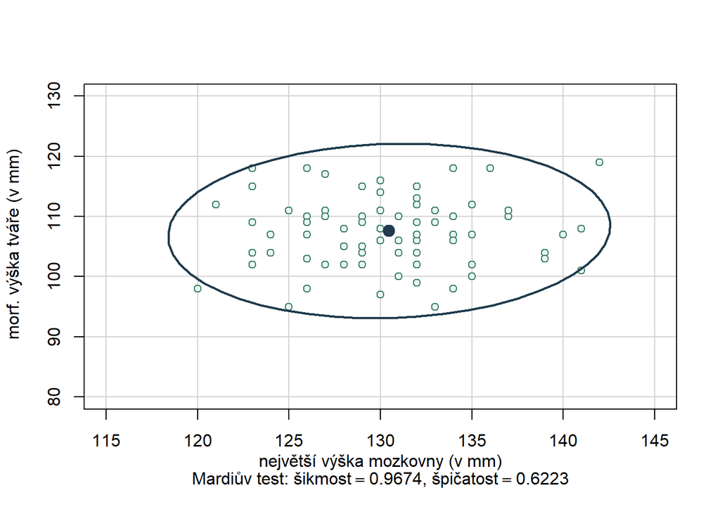

```r
car::dataEllipse(skull_F, face_F, level = 0.95, xlim = c(115, 145),
                 ylim = c(80, 130), pch = 21, bg = "#e8f7f0", col = c('#3A7D66', '#1F3B4D'),
                 ylab = " morf. výška tváře (v mm)", xlab = "")
mtext("největší výška mozkovny (v mm)", side = 1, line = 2)
mtext(bquote(paste("Mardiův test: šikmost" == .(round(p_vals_F[1], 4)), ', ',
                   "špičatost" == .(round(p_vals_F[2], 4)))), side = 1, line = 3)
```

## Test o rozdílu korelačních koeficientů $(\rho_1 - \rho_2)$

```r
rho0 <- 0
alpha <- 0.05
ksi0 <- (1/2) * log((1 + rho0)/(1 - rho0))

n_M <- length(skull_M)
n_F <- length(skull_F)

r_M <- cor(skull_M, face_M)
r_F <- cor(skull_F, face_F)

z_M <- (1/2) * log((1 + r_M)/(1 - r_M))
z_F <- (1/2) * log((1 + r_F)/(1 - r_F))


# testovani pomoci kritickeho oboru

zW <- ((z_M - z_F) - ksi0) / (sqrt((1/(n_M - 3)) + (1/(n_F - 3))))
q1 <- qnorm(alpha / 2, 0, 1)
q2 <- qnorm(1 - alpha/2, 0, 1)

rho_hat <- function(r, r_M, r_F, n_M, n_F) {
n_M * (r_M - r)/(1 - r_M * r) +  n_F * (r_F - r)/(1 - r_F * r)
}
r <- uniroot(rho_hat, interval = c(-1, 1), r_M = r_M, r_F = r_F, n_M = n_M, n_F = n_F)$root
uLR <- n_M * log((1 - r_M * r)^2 / ((1 - r^2) * (1 - r_M^2))) +  n_F * log((1 - r_F * r)^2 / ((1 - r^2) * (1 - r_F^2)))
q <- qchisq(1 - alpha, 1)


# testovani pomoci intervalu spolehlivosti

sigma2 <- 1/(n_M - 3) + 1/(n_F - 3)
dh_zR <- (z_M - z_F) - (q2 * sqrt(sigma2))
hh_zR <- (z_M - z_F) + (q2 * sqrt(sigma2))
dh_R <- tanh(dh_zR)
hh_R <- tanh(hh_zR)


# testovani pomoci p-hodnoty

p_ZW <- 2 * min(pnorm(zW), 1 - pnorm(zW))
p_uLR <- 1 - pchisq(uLR, 1)


# tabulka s vysledky

tab <- data.frame(
  rho = c(r_M - r_F, r_M - r_F),
  statistika = c(zW, uLR),
  Whh = c(q1, NA),
  Wdh = c(q2, q),
  IS.dh = c(dh_R, NA),
  IS.hh = c(hh_R, NA),
  p_hodnota = c(p_ZW, p_uLR))
names(tab) <- c("odhad rozdílu", "statistika", "$W_{hh}$", "$W_{dh}$",
                "$IS_{dh}$", "$IS_{hh}$", "$p$-hodnota")
rownames(tab) <- c("Waldův přístup", "Věrohodnostní přístup")

tab <- round(tab, digits = 4)

knitr::kable(tab, digits = 3, escape = FALSE)
```

|  | odhad rozdílu | statistika | $W_{hh}$ | $W_{dh}$ | $IS_{dh}$ | $IS_{hh}$ | $p$-hodnota |
| --- | --- | --- | --- | --- | --- | --- | --- |
| Waldův přístup | 0.266 | 1.998 | -1.96 | 1.960 | 0.005 | 0.503 | 0.046 |
| Věrohodnostní přístup | 0.266 | 4.105 | NA | 3.841 | NA | NA | 0.043 |

## Grafická vizualizace

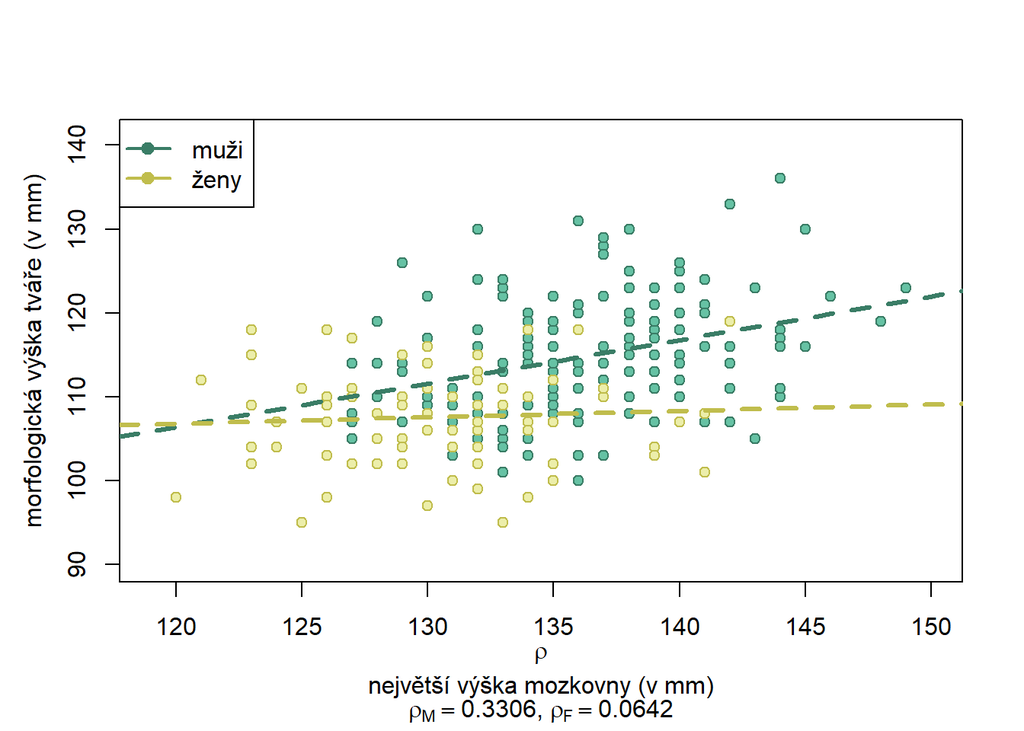

```r
col_M <- '#3A7D66'
bg_M <-'#66c2a4'
col_F <- '#c0bd4d'
bg_F <- "#eceeaa"

plot(skull_M, face_M, xlab = "", ylab = "", type = "p", pch = 21, bg = bg_M, col = col_M, ylim = c(min(face_F) - 5, max(face_M) + 5), xlim = c(min(skull_F) - 1, max(skull_M) + 1))
points(skull_F, face_F, bg = bg_F, col = col_F, pch = 21)
abline(lm(face_M ~ skull_M), col = col_M, lwd = 3, lty = 2)
abline(lm(face_F ~ skull_F), col = col_F, lwd = 3, lty = 2)
legend("topleft", legend = c("muži", "ženy"), pch = 19, lty = 1, col = c(col_M, col_F), lwd = 2)
mtext("největší výška mozkovny (v mm)", side = 1, line = 3)
mtext(expression(rho), side = 1, line = 2)

mtext(bquote(paste(rho[M] == .(round(r_M, 4)), ', ',
                   rho["F"] == .(round(r_F, 4)))), side = 1, line = 4)
mtext("morfologická výška tváře (v mm)", side = 2, line = 2.5)
```